# C1 Activity Models - Longitudinal Models of the MIECHV Effectiveness and Statewide Trends

OUHSC MIECHV External Evaluation Team

# 1 Modeling and Graphical Analysis

```
Suitable Referrals
```

```
               coefficient letter   beta change     p
1               MiechvEver      a -0.565   0.57  .001
2                  Cohort1      b -0.086   0.92  .292
3                  Cohort2      c -0.341   0.71  .007
4 Cohort1:MiechvContracted      d  0.022   1.02  .837
5 Cohort2:MiechvContracted      e  0.150   1.16  .370
```

```
Completed Enrollments
```

```
               coefficient letter   beta change     p
1               MiechvEver      a -0.543   0.58  .001
2                  Cohort1      b -0.088   0.92  .283
3                  Cohort2      c -0.629   0.53 <.001
4 Cohort1:MiechvContracted      d -0.007   0.99  .949
5 Cohort2:MiechvContracted      e  0.233   1.26  .262
```

```
Completed Visits
```

```
               coefficient letter   beta change     p
1               MiechvEver      a -0.545   0.58  .001
2                  Cohort1      b -0.031   0.97  .314
3                  Cohort2      c -0.081   0.92  .096
4 Cohort1:MiechvContracted      d  0.045   1.05  .158
5 Cohort2:MiechvContracted      e  0.090   1.09  .152
```

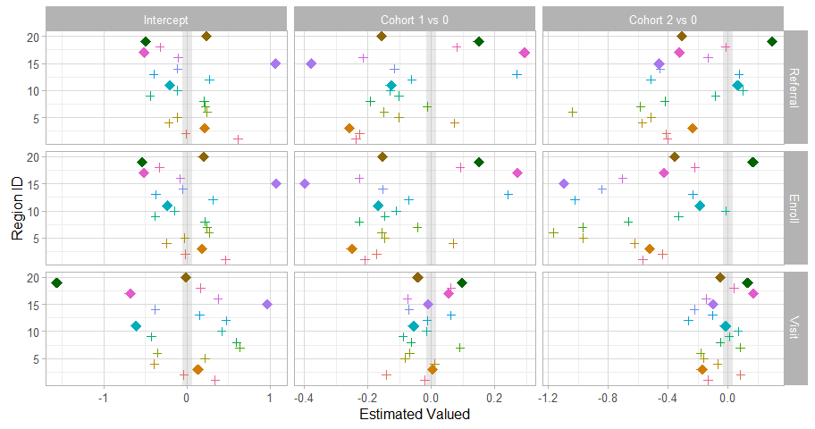

```
Generalized linear mixed model fit by maximum likelihood (Adaptive Gauss-Hermite Quadrature, nAGQ
  = 0) [glmerMod]
 Family: poisson  ( log )
Formula: EnrollCompletedCount ~ 1 + MiechvEver + Cohort1 + Cohort2 + MiechvContracted:Cohort1 +
    MiechvContracted:Cohort2 + (1 + Cohort1 + Cohort2 | RegionID) +
    (1 | QuarterF) + offset(log(ReferralCompleteCountMean3Months))
   Data: dsRegionMonth2

     AIC      BIC   logLik deviance df.resid
  6934.4   7004.6  -3454.2   6908.4     1627

Scaled residuals:
    Min      1Q  Median      3Q     Max
-2.6193 -0.7466 -0.0242  0.5915  5.4015

Random effects:
 Groups   Name        Variance  Std.Dev. Corr
 QuarterF (Intercept) 2.499e-03 0.049986
 RegionID (Intercept) 6.133e-06 0.002477
          Cohort1     1.733e-05 0.004163 -1.00
          Cohort2     1.617e-02 0.127166  1.00 -1.00
Number of obs: 1640, groups:  QuarterF, 28; RegionID, 20

Fixed effects:
                          Estimate Std. Error z value Pr(>|z|)
(Intercept)              -0.010762   0.022027  -0.489   0.6251
MiechvEver               -0.001708   0.026335  -0.065   0.9483
Cohort1                  -0.020403   0.034877  -0.585   0.5586
Cohort2                  -0.396190   0.070551  -5.616 1.96e-08 ***
Cohort1:MiechvContracted  0.001931   0.041758   0.046   0.9631
Cohort2:MiechvContracted  0.201355   0.102142   1.971   0.0487 *
---
Signif. codes:  0 '***' 0.001 '**' 0.01 '*' 0.05 '.' 0.1 ' ' 1

Correlation of Fixed Effects:
            (Intr) MchvEv Cohrt1 Cohrt2 Ch1:MC
MiechvEver  -0.523
Cohort1     -0.632  0.331
Cohort2     -0.296  0.150  0.180
Chrt1:MchvC  0.330 -0.632 -0.537 -0.089
Chrt2:MchvC  0.124 -0.221 -0.073 -0.579  0.123
```

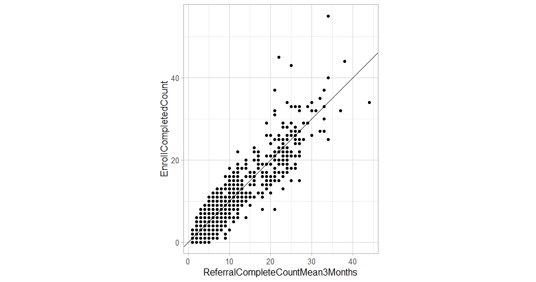

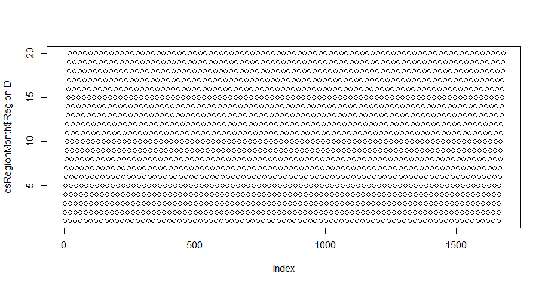

This report covers the longitudinal models of the MIECHV effectiveness and of statewide trends. It is relevant to Aim 1C (“Evaluate the frequency of referrals coming into EBHV agencies”), Aim 3A (“Continually evaluate the flow of clients served per county”), Aim 3D (“Evaluate effectiveness of new engagement enhancement strategies”), and Aim 5C (“Implement and evaluate system of quality improvements and controls”) of [HRSA/ACF D89MC23154](http://ouhscbbmc.github.io/MReportingPublic/research-2011a.html) Investigation.

The underlying dataset contains information from 20 lead nurse regions, 11,373 completed referrals, 11,084 completed enrollments, and 241,430 completed visits. It summarizes C1 activity between 2009-01-15 and 2015-12-15. Time and effort data is available from 2012-06-15 to 2015-08-14. The date used for the introduction of MIECHV funds is 2012-06-15.

The processes for gathering and reshaping the C1 data was described in [C1 Activity Methods](http://ouhscbbmc.github.io/MReportingPublic/reports/2011/c1-activity-methods-description.pdf). Information about county and region demographics is available in [OSDH Maps](http://ouhscbbmc.github.io/MReportingPublic/reports/osdh-maps.html).

# 2 Milestones

One of this investigation’s goals is to assess if C1 performance changes following significant events in Oklahoma’s home visiting programs. The following dates are of particular interest. A more detailed is found on our project’s [interactive timeline](http://ouhscbbmc.github.io/MReportingPublic/reports/Aim1B.html).

|  | Start Date | Stop Date | Description |
| --- | --- | --- | --- |
| Cohort 0 | Jan 01, 2009 | Jun 14, 2012 | Comparison period before any MIECHV activities. |
| Community Connector | May 01, 2012 | Present | Community Connector,Community Connector contracts start. (Six counties in Summer & Fall 2012. Comanche stops July 2013. Garfield stops Sept 2014. Kay & Muskogee stops Sept 2015.) |
| Cohort 1 or 2 | Jun 15, 2012 | Present | Program funds are spent in the counties. |
| Cohort 1 | Jun 15, 2012 | Dec 31, 2014 | Program funds start being spent in the counties. |
| Cohort 2 | Jan 01, 2015 | Present | Program funds continue being spent in the counties. |
| Ad Waves | Apr 01, 2014 | Jun 30, 2015 | parentPRO ad campaigns in 2014 and 2015 |
| Ad Waves Lagged | Jun 01, 2014 | Jun 30, 2015 | parentPRO ad campaigns in 2014 and 2015 |
| Ad Wave 1 | Apr 01, 2014 | Jun 30, 2014 | parentPRO ad campaign concentrated in May. |
| Ad Wave 1 Lagged | Jun 01, 2014 | Jun 30, 2014 | parentPRO ad campaign concentrated in May. |
| Ad Wave 2 | Sep 01, 2014 | Oct 30, 2014 | parentPRO ad campaign concentrated in late Sept. |
| Ad Wave 2 Lagged | Oct 01, 2014 | Oct 30, 2014 | parentPRO ad campaign concentrated in late Sept. |
| Referral Restrictions Lifted | May 23, 2014 | Present | Substantial restrictions lifted for inter-agency collaboration. |
| ETO Transition | Jan 01, 2015 | Apr 30, 2015 | Staff transitions from OCAPPA data system to ETO (deployed Jan 1). |
| parentPRO Website | Apr 02, 2015 | Present | The state’s umbrella website is deployed. |
| Ad Wave 3 | May 01, 2015 | Jun 30, 2015 | parentPRO ad campaign concentrated in late May. |
| Ad Wave 3 Lagged | Jun 01, 2015 | Jun 30, 2015 | parentPRO ad campaign concentrated in late May. |

```
         EraWebsite
EraLifted FALSE TRUE
    FALSE  1440  126
    TRUE     60   54
```

```
         HasConnector
EraLifted FALSE TRUE
    FALSE  1438  128
    TRUE     28   86
```

```
          HasConnector
EraWebsite FALSE TRUE
     FALSE  1322  178
     TRUE    144   36
```

# 3 Modeling and Graphical Analysis

The outcomes of interest involve the referrals, enrollments, and visits of a C1 region. The MIECHV treatment is operationalized in three ways. In Model 1, a region’s treatment effect reflects the time period when at least one county was *under contract* with OSDH; the corresponding coefficients are 1a-1g. In Model 2, the treatment effect reflects when a region *had at least one MIECHV-funded nurse on staff*; the corresponding coefficients are 2a-2g. In Model 3, the treatment effect reflects when a region *had at least one ParentPRO community connector*.

Models 4 through 7 examine specific events related to the service, and combine cohorts 1 and 2 into a single uniform period. Whereas the first three models define MIECHV differently from each other, these last four models evalute the event’s explanatory power *after MIECHV has been included in a model*. In a sense, these models estimate how much their event explains beyond what the MIECHV variable is already explaining.

A two-level Poisson family is used in each model; the outcome at each month is nested within region. The Poisson offset is the region’s number of infants in need, which help make the regions’ estimates more comparable. Level 1 estimates an intercept and a lag-3 autocorrelation for each region. Level 2 contains two classes of variables: the first attempts to partial out variability unrelated to MIECHV events, while the second addresses the investigation’s hypotheses. The first class estimates the overall level for each quarter year (to remove seasonal and secular trends) and a lag-3 autocorrelation (to control for longitudinal dependencies). The second class estimates a coefficient for the following seven comparisons.

| Coefficient | Label | Description |
| --- | --- | --- |
| a | 0 - NvM | non-MIECHV vs MIECHV at Cohort 0 |
| b | 0v1 - N | Cohort 0vs1 among NonMIECHV |
| c | 0v2 - N | Cohort 0vs2 among NonMIECHV |
| d | 0v1 - NvM | Cohort 0vs1 - non-MIECHV vs MIECHV |
| e | 0v2 - NvM | Cohort 0vs2 - non-MIECHV vs MIECHV |
| f | 1v2 - N | Cohort 1vs2 among NonMIECHV |
| g | 1v2 - NvM | Cohort 1vs2 - non-MIECHV vs MIECHV |

The `change` represents the proportion difference attributed to each effect, beyond the influence of the model’s other terms. The change value is calculated by $change = e^{est}$. For example, a value of 1.26 for *d* indicates that the effect contributed to a 26% increase in the outcome. The main text contains only the salient coefficients listed above; comprehensive model output is available in the appendix and [online](http://ouhscbbmc.github.io/MReportingPublic/reports/2011/c1-activity-methods-description.pdf).

Coefficients for *d* and *e* are the most relevant to the investigation –they compare how MIECHV changed versus how non-MIECHV changed. A value above 1.00 indicates that the 6 MIECHV regions are increasing more than the 14 comparison regions are increasing (or alternatively, that they are decreasing less). Coefficient *d* compares this ‘difference of change’ between cohorts 0 and 1, while *e* compares between 0 and 2. Arguably this is more important than comparing non-MIECHV against MIECHV for a given cohort, but because this considers where they two groups started from (and therefore, if the MIECHV intervention altered the natural trajectory, represented by the comparison regions).

Coefficient *f* estimates how non-MIECHV regions changed between cohorts 1 and 2, while *g* estimates how MIECHV regions changed over this same time period, *relative* to the non-MIECHV regions. A value greater than 1.00 indicates cohort 2 was greater than cohort 1. These point estimates can be calculated from the previous coefficients (*f* = *c*/*b* and *g* = *e*/*d*), but the *p*-values cannot. Because *g* is relative, the *absolute* change for MIECHV regions is found by multiplying *f* and *g*. (Note: because the Poisson family uses a loglinear link function, the change coefficients are multiplied and divided, instead of summed and subtracted.)

**MIECHV Contracted**

- Model 1: *MIECHV Contracted*: This indicator variable reflects the months each region had at least one MIECHV county under contract. The two formula grant counties (ie, Kay and Garfield) started in May 2011, while the four competition grant counties (ie, Comanche, Muskogee, Oklahoma, and Tulsa) started in October 2011. Coefficients *a*-*g* are reported for Model 1.

**MIECHV Staffed**

- Model 2: *MIECHV Nurses Staffed*: Some counties hired MIECHV-funded nurses in April 2012, while some could not fill it reliably until the summer of 2014. The model uses the `MiechvStaffed` variable, which is 1 during any month the region has at least one MIECHV-funded nurse, and 0 otherwise. Coefficients *a*-*g* are reported for Model 2.

**Community Connector**

**Isolated Events**

Additionally, a model was run for each of the four events to estimate its correspondence with each outcome. The change associated with the event is the only coefficient listed in the main text. Although the other coefficients in the event models differ from each other and from the three-cohort model, they are similar enough to exclude in the main text. Comprehensive model output is available in the appendix and online. A model was run for each of the following events:

- Model 4: *First marketing wave*. The model accounts for the seven months of ParentPRO advertisements in 2014 across the state. Although residents in MIECHV areas were the focus of this campaign, practically the whole state was exposed (particularly through the day-time television commercials brought in the state’s substantial populations centers). The campaign included internet, television, radio, and transit advertisements.
- Model 5: *Referral Restrictions Lifted*. Substantial interagency obstacles were removed in May 2014 for the six MIECHV regions in order to make referrals more time efficient.
- Model 6: *ParentPRO website*. A [client-focused website](http://www.parentpro.org/) was deployed in April 2015. Like the two marketing waves, this was deployed state-wide.
- Model 7: *Second marketing wave*. This period during 2015 is handled similarly to the first marketing wave.

A Poisson family was chosen because it typically models counts well, such as the count of referrals in a month. For additional assurance, a conventional model with a Gaussian family was run on an equivalent outcome. For instance, when the Poisson outcome and offset were ‘Referral Count’ and ‘Infant Need Count’ the accompanying Gaussian outcome was simply ‘Referral Count per Infants in Need’. The two approaches lead to comparable conclusions, and only the Poisson is reported.

# 4 Referrals

**Three cohorts**

Model 2’s estimates corresponded very closely to Model 1, suggesting that the two operationalizations of the MIECHV treatment are comparable for suitable referrals. Model 3’s estimates also closely correspond to Model 1; the one visible difference is that cohort 1’s level was smaller, which weakened *3d* (which estimates MIECHV’s differential gain over non-MIECHV regions between cohorts 0 and 1) and strengthened *3g* (the differential gain between cohorts 1 and 2).

```
            MIECHV Contracted      MIECHV Staffed       Has Connector
                 Change     p        Change     p        Change     p
  0 - NvM :   1a   0.74 <.001     2a   0.78  .001     3a   0.77  .002
0v1 - N   :   1b   0.99  .847     2b   1.01  .786     3b   1.03  .534
0v2 - N   :   1c   0.90  .012     2c   0.93  .103     3c   0.92  .055
0v1 - NvM :   1d   1.14 <.001     2d   1.12 <.001     3d   1.04  .228
0v2 - NvM :   1e   1.26 <.001     2e   1.18 <.001     3e   1.22 <.001

1v2 - N   :   1f   0.91  .055     2f   0.92  .106     3f   0.90  .031
1v2 - NvM :   1g   1.11  .003     2g   1.06  .128     3g   1.17 <.001
```

**Individual Events**

```
         Event  Change     p
4    AdWaveAny    0.96  .319
5      AdWave1    1.03  .607
6      AdWave2    1.03  .572
7    EraLifted    1.08  .030
8   EraWebsite    0.94  .210
9      AdWave3    0.86  .014
```

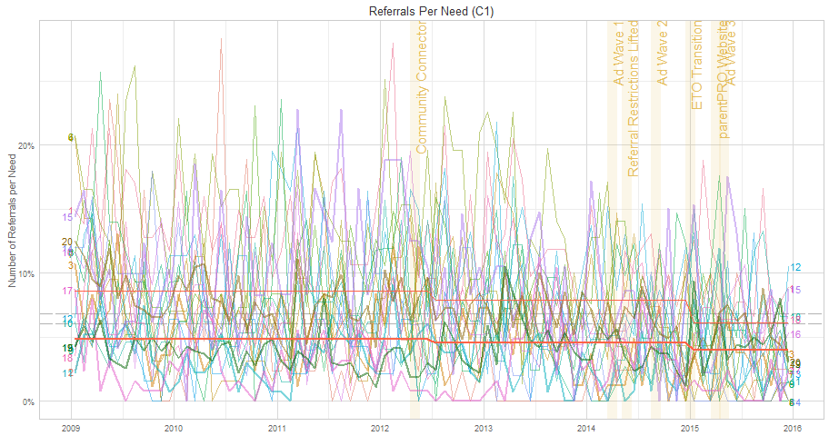

*Response variable*: `ReferralCompleteCount`; *Offset variable*: `InfantNeedCountForTime`

## 4.1 Two-rate coding –MIECHV Contracted

```
               coefficient letter   beta change     p
1               MiechvEver      a -0.565   0.57  .001
2                  Cohort1      b -0.086   0.92  .292
3                  Cohort2      c -0.341   0.71  .007
4 Cohort1:MiechvContracted      d  0.022   1.02  .837
5 Cohort2:MiechvContracted      e  0.150   1.16  .370
Generalized linear mixed model fit by maximum likelihood (Adaptive Gauss-Hermite Quadrature, nAGQ
  = 0) [glmerMod]
 Family: poisson  ( log )
Formula: ReferralCompleteCount ~ 1 + MiechvEver + Cohort1 + Cohort2 +
    MiechvContracted:Cohort1 + MiechvContracted:Cohort2 + Lag1 +
    Lag2 + Lag3 + (1 + Cohort1 + Cohort2 + Lag1 + Lag2 + Lag3 |
    RegionID) + (1 | QuarterF) + offset(log(InfantNeedCountForTime))
   Data: d

     AIC      BIC   logLik deviance df.resid
  7975.8   8142.9  -3956.9   7913.8     1589

Random effects:
 Groups   Name        Variance  Std.Dev. Corr
 QuarterF (Intercept) 0.0175915 0.13263
 RegionID (Intercept) 0.1601920 0.40024
          Cohort1     0.0364567 0.19094  -0.68
          Cohort2     0.1037230 0.32206  -0.51  0.26
          Lag1        0.0011825 0.03439  -0.60  0.18 -0.24
          Lag2        0.0024474 0.04947  -0.43  0.11 -0.22  0.89
          Lag3        0.0002638 0.01624  -0.45 -0.26  0.70  0.23  0.21
Number of obs: 1620, groups:  QuarterF, 27; RegionID, 20

Fixed effects:
                         Estimate Std. Error z value Pr(>|z|)
(Intercept)              -2.68099    0.11235 -23.862  < 2e-16 ***
MiechvEver               -0.56500    0.16329  -3.460 0.000540 ***
Cohort1                  -0.08571    0.08139  -1.053 0.292324
Cohort2                  -0.34102    0.12569  -2.713 0.006665 **
Lag1                      0.03210    0.01122   2.862 0.004215 **
Lag2                      0.05088    0.01416   3.594 0.000326 ***
Lag3                      0.03511    0.00880   3.990 6.61e-05 ***
Cohort1:MiechvContracted  0.02151    0.10453   0.206 0.836976
Cohort2:MiechvContracted  0.14981    0.16713   0.896 0.370073
---
Signif. codes:  0 '***' 0.001 '**' 0.01 '*' 0.05 '.' 0.1 ' ' 1
```

### 4.1.1 Increment coding –MIECHV Contracted

```
                  coefficient letter   beta change     p
1                  MiechvEver      a -0.627   0.53 <.001
2                  Cohort1Or2      b -0.084   0.92  .157
3                     Cohort2      c -0.195   0.82  .028
4 Cohort1Or2:MiechvContracted      d  0.048   1.05  .258
5    Cohort2:MiechvContracted      e  0.209   1.23  .002
      AIC       BIC    logLik  deviance  df.resid
 8049.980  8157.783 -4004.990  8009.980  1600.000
```

## 4.2 Two-rate coding –MIECHV Staffed

```
            coefficient letter   beta change     p
1            MiechvEver      a -0.573   0.56 <.001
2               Cohort1      b -0.088   0.92  .244
3               Cohort2      c -0.348   0.71  .003
4 Cohort1:MiechvStaffed      d  0.045   1.05  .430
5 Cohort2:MiechvStaffed      e  0.195   1.22  .070
      AIC       BIC    logLik  deviance  df.resid
 7973.015  8140.110 -3955.507  7911.015  1589.000
```

### 4.2.1 Increment coding –MIECHV Staffed

```
               coefficient letter   beta change     p
1               MiechvEver      a -0.607   0.54 <.001
2               Cohort1Or2      b -0.080   0.92  .174
3                  Cohort2      c -0.199   0.82  .022
4 Cohort1Or2:MiechvStaffed      d  0.048   1.05  .242
5    Cohort2:MiechvStaffed      e  0.279   1.32 <.001
      AIC       BIC    logLik  deviance  df.resid
 8039.298  8147.102 -3999.649  7999.298  1600.000
```

## 4.3 Two-rate coding –Has Community Connector

```
           coefficient letter   beta change     p
1           MiechvEver      a -0.573   0.56 <.001
2              Cohort1      b -0.067   0.94  .383
3              Cohort2      c -0.389   0.68  .001
4 Cohort1:HasConnector      d -0.051   0.95  .497
5 Cohort2:HasConnector      e  0.384   1.47  .006
      AIC       BIC    logLik  deviance  df.resid
 7969.709  8136.804 -3953.854  7907.709  1589.000
```

### 4.3.1 Increment coding –Has Community Connector

```
              coefficient letter   beta change     p
1              MiechvEver      a -0.620   0.54 <.001
2              Cohort1Or2      b -0.061   0.94  .296
3                 Cohort2      c -0.234   0.79  .008
4 Cohort1Or2:HasConnector      d -0.002   1.00  .967
5    Cohort2:HasConnector      e  0.315   1.37 <.001
      AIC       BIC    logLik  deviance  df.resid
 8040.757  8148.561 -4000.379  8000.757  1600.000
```

## 4.4 Event: Ad Waves

*Event Description*: parentPRO ad campaigns in 2014 and 2015 - Apr 01, 2014

```
  coefficient letter   beta change     p
1   AdWaveAny      h -0.124   0.88  .002
2  Cohort1Or2      i -0.050   0.95  .016
      AIC       BIC    logLik  deviance  df.resid
 8165.279  8251.522 -4066.640  8133.279  1604.000
```

## 4.5 Event: Ad Waves Lagged

*Event Description*: parentPRO ad campaigns in 2014 and 2015 - Jun 01, 2014

```
      coefficient letter   beta change     p
1 AdWaveAnyLagged      h -0.190   0.83  .001
2      Cohort1Or2      i -0.056   0.95  .005
      AIC       BIC    logLik  deviance  df.resid
 8164.546  8250.788 -4066.273  8132.546  1604.000
```

## 4.6 Event: Ad Wave 1

*Event Description*: parentPRO ad campaign concentrated in May. - Apr 01, 2014

```
  coefficient letter   beta change     p
1     AdWave1      h -0.053   0.95  .348
2  Cohort1Or2      i -0.064   0.94  .001
      AIC       BIC    logLik  deviance  df.resid
 8174.487  8260.730 -4071.244  8142.487  1604.000
```

## 4.7 Event: Ad Wave 1 Lagged

*Event Description*: parentPRO ad campaign concentrated in May. - Jun 01, 2014

```
    coefficient letter   beta change     p
1 AdWave1Lagged      h -0.112   0.89  .254
2    Cohort1Or2      i -0.067   0.94  .001
      AIC       BIC    logLik  deviance  df.resid
 8194.899  8281.142 -4081.449  8162.899  1604.000
```

## 4.8 Event: Ad Wave 2

*Event Description*: parentPRO ad campaign concentrated in late Sept. - Sep 01, 2014

```
  coefficient letter   beta change     p
1     AdWave2      h -0.185   0.83  .008
2  Cohort1Or2      i -0.059   0.94  .003
      AIC       BIC    logLik  deviance  df.resid
 8167.821  8254.064 -4067.910  8135.821  1604.000
```

## 4.9 Event: Ad Wave 2 Lagged

*Event Description*: parentPRO ad campaign concentrated in late Sept. - Oct 01, 2014

```
    coefficient letter   beta change     p
1 AdWave2Lagged      h -0.242   0.79  .017
2    Cohort1Or2      i -0.062   0.94  .002
      AIC       BIC    logLik  deviance  df.resid
 8169.064  8255.307 -4068.532  8137.064  1604.000
```

## 4.10 Event: Referral Restrictions Lifted

*Event Description*: Substantial restrictions lifted for inter-agency collaboration. - May 23, 2014

```
  coefficient letter   beta change     p
1   EraLifted      h -0.092   0.91  .019
2  Cohort1Or2      i -0.051   0.95  .016
      AIC       BIC    logLik  deviance  df.resid
 8169.783  8256.025 -4068.891  8137.783  1604.000
```

## 4.11 Event: ETO Transition

*Event Description*: Staff transitions from OCAPPA data system to ETO (deployed Jan 1). - Jan 01, 2015

```
    coefficient letter   beta change     p
1 EtoTransition      h  0.054   1.06  .279
2    Cohort1Or2      i -0.072   0.93 <.001
      AIC       BIC    logLik  deviance  df.resid
 8174.022  8260.265 -4071.011  8142.022  1604.000
```

## 4.12 Event: parentPRO Website

*Event Description*: The state’s umbrella website is deployed. - Apr 02, 2015

```
  coefficient letter   beta change     p
1  EraWebsite      h -0.108   0.90  .004
2  Cohort1Or2      i -0.050   0.95  .015
      AIC       BIC    logLik  deviance  df.resid
 8166.942  8253.185 -4067.471  8134.942  1604.000
```

## 4.13 Event: Ad Wave 3

*Event Description*: parentPRO ad campaign concentrated in late May. - May 01, 2015

```
  coefficient letter   beta change     p
1     AdWave3      h -0.120   0.89  .102
2  Cohort1Or2      i -0.063   0.94  .002
      AIC       BIC    logLik  deviance  df.resid
 8172.417  8258.660 -4070.208  8140.417  1604.000
```

## 4.14 Event: Ad Wave 3 Lagged

*Event Description*: parentPRO ad campaign concentrated in late May. - Jun 01, 2015

```
    coefficient letter   beta change     p
1 AdWave3Lagged      h -0.184   0.83  .080
2    Cohort1Or2      i -0.064   0.94  .001
      AIC       BIC    logLik  deviance  df.resid
 8171.929  8258.172 -4069.965  8139.929  1604.000
```

# 5 Enrollments

The next batch of models assessed MIECHV’s effect on completed enrollments, which occurs after the client’s first completed visit.

**Three cohorts**

The esimates from Models 2 and 3 corresponded closely to Model 1, suggesting that the three operationalizations of the MIECHV treatment are comparable for completed enrollments. The only notable difference involves coefficient *g*. The Model 2 and 3 estimates are about 5%, at which point coefficients become significant; this suggests MIECHV regions did relatively better than non-MIECHV regions between cohorts 1 and 2.

```
            MIECHV Contracted      MIECHV Staffed       Has Connector
                 Change     p        Change     p        Change     p
  0 - NvM :   1a   0.65 <.001     2a   0.65 <.001     3a   0.67 <.001
0v1 - N   :   1b   0.98  .776     2b   0.99  .910     3b   1.01  .880
0v2 - N   :   1c   0.80 <.001     2c   0.80 <.001     3c   0.82  .001
0v1 - NvM :   1d   1.06  .216     2d   1.05  .303     3d   1.00  .936
0v2 - NvM :   1e   1.15  .004     2e   1.19 <.001     3e   1.11  .028

1v2 - N   :   1f   0.81  .005     2f   0.80  .002     3f   0.81  .004
1v2 - NvM :   1g   1.09  .144     2g   1.13  .040     3g   1.12  .057
```

**Individual Events**

[output not shown]

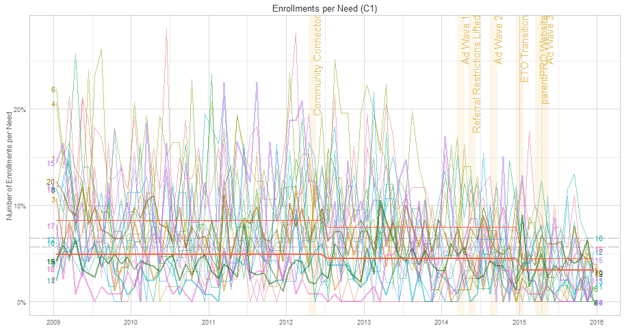

*Response variable*: `EnrollCompletedCount`; *Offset variable*: `InfantNeedCountForTime`

## 5.1 Two-rate coding –MIECHV Contracted

```
               coefficient letter   beta change     p
1               MiechvEver      a -0.543   0.58  .001
2                  Cohort1      b -0.088   0.92  .283
3                  Cohort2      c -0.629   0.53 <.001
4 Cohort1:MiechvContracted      d -0.007   0.99  .949
5 Cohort2:MiechvContracted      e  0.233   1.26  .262
Generalized linear mixed model fit by maximum likelihood (Adaptive Gauss-Hermite Quadrature, nAGQ
  = 0) [glmerMod]
 Family: poisson  ( log )
Formula: EnrollCompletedCount ~ 1 + MiechvEver + Cohort1 + Cohort2 + MiechvContracted:Cohort1 +
    MiechvContracted:Cohort2 + Lag1 + Lag2 + Lag3 + (1 + Cohort1 +
    Cohort2 + Lag1 + Lag2 + Lag3 | RegionID) + (1 | QuarterF) +
    offset(log(InfantNeedCountForTime))
   Data: d

     AIC      BIC   logLik deviance df.resid
  7844.7   8011.8  -3891.4   7782.7     1589

Random effects:
 Groups   Name        Variance  Std.Dev. Corr
 QuarterF (Intercept) 0.0183329 0.13540
 RegionID (Intercept) 0.1545976 0.39319
          Cohort1     0.0357394 0.18905  -0.68
          Cohort2     0.1566972 0.39585  -0.66  0.40
          Lag1        0.0012328 0.03511  -0.55  0.15  0.18
          Lag2        0.0025087 0.05009  -0.42  0.27  0.23  0.91
          Lag3        0.0002687 0.01639  -0.33 -0.44  0.40  0.26 -0.05
Number of obs: 1620, groups:  QuarterF, 27; RegionID, 20

Fixed effects:
                          Estimate Std. Error z value Pr(>|z|)
(Intercept)              -2.702975   0.111680 -24.203  < 2e-16 ***
MiechvEver               -0.542869   0.166546  -3.260 0.001116 **
Cohort1                  -0.087938   0.081835  -1.075 0.282564
Cohort2                  -0.628509   0.145089  -4.332 1.48e-05 ***
Lag1                      0.031831   0.011379   2.797 0.005151 **
Lag2                      0.054834   0.014280   3.840 0.000123 ***
Lag3                      0.036316   0.009244   3.929 8.54e-05 ***
Cohort1:MiechvContracted -0.006558   0.103070  -0.064 0.949271
Cohort2:MiechvContracted  0.232520   0.207472   1.121 0.262402
---
Signif. codes:  0 '***' 0.001 '**' 0.01 '*' 0.05 '.' 0.1 ' ' 1
```

### 5.1.1 Increment coding –MIECHV Contracted

```
                  coefficient letter   beta change     p
1                  MiechvEver      a -0.559   0.57 <.001
2                  Cohort1Or2      b -0.092   0.91  .126
3                     Cohort2      c -0.428   0.65 <.001
4 Cohort1Or2:MiechvContracted      d  0.055   1.06  .193
5    Cohort2:MiechvContracted      e  0.302   1.35 <.001
      AIC       BIC    logLik  deviance  df.resid
 7914.816  8022.620 -3937.408  7874.816  1600.000
```

## 5.2 Two-rate coding –MIECHV Staffed

```
            coefficient letter   beta change     p
1            MiechvEver      a -0.545   0.58 <.001
2               Cohort1      b -0.096   0.91  .210
3               Cohort2      c -0.611   0.54 <.001
4 Cohort1:MiechvStaffed      d  0.028   1.03  .619
5 Cohort2:MiechvStaffed      e  0.200   1.22  .100
      AIC       BIC    logLik  deviance  df.resid
 7843.376  8010.472 -3890.688  7781.376  1589.000
```

### 5.2.1 Increment coding –MIECHV Staffed

```
               coefficient letter   beta change     p
1               MiechvEver      a -0.523   0.59 <.001
2               Cohort1Or2      b -0.083   0.92  .165
3                  Cohort2      c -0.393   0.67 <.001
4 Cohort1Or2:MiechvStaffed      d  0.041   1.04  .311
5    Cohort2:MiechvStaffed      e  0.320   1.38 <.001
      AIC       BIC    logLik  deviance  df.resid
 7912.869  8020.673 -3936.434  7872.869  1600.000
```

## 5.3 Two-rate coding –Has Community Connector

```
           coefficient letter   beta change     p
1           MiechvEver      a -0.508   0.60 <.001
2              Cohort1      b -0.071   0.93  .355
3              Cohort2      c -0.631   0.53 <.001
4 Cohort1:HasConnector      d -0.066   0.94  .376
5 Cohort2:HasConnector      e  0.339   1.40  .047
      AIC       BIC    logLik  deviance  df.resid
 7841.016  8008.112 -3889.508  7779.016  1589.000
```

### 5.3.1 Increment coding –Has Community Connector

```
              coefficient letter   beta change     p
1              MiechvEver      a -0.543   0.58 <.001
2              Cohort1Or2      b -0.069   0.93  .249
3                 Cohort2      c -0.460   0.63 <.001
4 Cohort1Or2:HasConnector      d  0.003   1.00  .941
5    Cohort2:HasConnector      e  0.399   1.49 <.001
      AIC       BIC    logLik  deviance  df.resid
 7906.333  8014.137 -3933.167  7866.333  1600.000
```

## 5.4 Event: Ad Waves

*Event Description*: parentPRO ad campaigns in 2014 and 2015 - Apr 01, 2014

```
  coefficient letter   beta change     p
1   AdWaveAny      h -0.138   0.87  .001
2  Cohort1Or2      i -0.079   0.92 <.001
      AIC       BIC    logLik  deviance  df.resid
 8073.262  8159.505 -4020.631  8041.262  1604.000
```

## 5.5 Event: Ad Waves Lagged

*Event Description*: parentPRO ad campaigns in 2014 and 2015 - Jun 01, 2014

```
      coefficient letter   beta change     p
1 AdWaveAnyLagged      h -0.182   0.83  .003
2      Cohort1Or2      i -0.088   0.92 <.001
      AIC       BIC    logLik  deviance  df.resid
 8075.605  8161.848 -4021.802  8043.605  1604.000
```

## 5.6 Event: Ad Wave 1

*Event Description*: parentPRO ad campaign concentrated in May. - Apr 01, 2014

```
  coefficient letter   beta change     p
1     AdWave1      h -0.014   0.99  .808
2  Cohort1Or2      i -0.098   0.91 <.001
      AIC       BIC    logLik  deviance  df.resid
 8084.725  8170.968 -4026.362  8052.725  1604.000
```

## 5.7 Event: Ad Wave 1 Lagged

*Event Description*: parentPRO ad campaign concentrated in May. - Jun 01, 2014

```
    coefficient letter   beta change     p
1 AdWave1Lagged      h -0.083   0.92  .400
2    Cohort1Or2      i -0.097   0.91 <.001
      AIC       BIC    logLik  deviance  df.resid
 8084.062  8170.305 -4026.031  8052.062  1604.000
```

## 5.8 Event: Ad Wave 2

*Event Description*: parentPRO ad campaign concentrated in late Sept. - Sep 01, 2014

```
  coefficient letter   beta change     p
1     AdWave2      h -0.164   0.85  .020
2  Cohort1Or2      i -0.091   0.91 <.001
      AIC       BIC    logLik  deviance  df.resid
 8079.138  8165.381 -4023.569  8047.138  1604.000
```

## 5.9 Event: Ad Wave 2 Lagged

*Event Description*: parentPRO ad campaign concentrated in late Sept. - Oct 01, 2014

```
    coefficient letter   beta change     p
1 AdWave2Lagged      h -0.210   0.81  .039
2    Cohort1Or2      i -0.094   0.91 <.001
      AIC       BIC    logLik  deviance  df.resid
 8080.248  8166.491 -4024.124  8048.248  1604.000
```

## 5.10 Event: Referral Restrictions Lifted

*Event Description*: Substantial restrictions lifted for inter-agency collaboration. - May 23, 2014

```
  coefficient letter   beta change     p
1   EraLifted      h -0.166   0.85 <.001
2  Cohort1Or2      i -0.069   0.93  .001
      AIC       BIC    logLik  deviance  df.resid
 8068.441  8154.683 -4018.220  8036.441  1604.000
```

## 5.11 Event: ETO Transition

*Event Description*: Staff transitions from OCAPPA data system to ETO (deployed Jan 1). - Jan 01, 2015

```
    coefficient letter   beta change     p
1 EtoTransition      h -0.098   0.91  .075
2    Cohort1Or2      i -0.092   0.91 <.001
      AIC       BIC    logLik  deviance  df.resid
 8081.614  8167.857 -4024.807  8049.614  1604.000
```

## 5.12 Event: parentPRO Website

*Event Description*: The state’s umbrella website is deployed. - Apr 02, 2015

```
  coefficient letter   beta change     p
1  EraWebsite      h -0.269   0.76 <.001
2  Cohort1Or2      i -0.064   0.94  .002
      AIC       BIC    logLik  deviance  df.resid
 8042.975  8129.218 -4005.488  8010.975  1604.000
```

## 5.13 Event: Ad Wave 3

*Event Description*: parentPRO ad campaign concentrated in late May. - May 01, 2015

```
  coefficient letter   beta change     p
1     AdWave3      h -0.281   0.75  .001
2  Cohort1Or2      i -0.091   0.91 <.001
      AIC       BIC    logLik  deviance  df.resid
 8072.509  8158.752 -4020.254  8040.509  1604.000
```

## 5.14 Event: Ad Wave 3 Lagged

*Event Description*: parentPRO ad campaign concentrated in late May. - Jun 01, 2015

```
    coefficient letter   beta change     p
1 AdWave3Lagged      h -0.247   0.78  .033
2    Cohort1Or2      i -0.095   0.91 <.001
      AIC       BIC    logLik  deviance  df.resid
 8079.921  8166.163 -4023.960  8047.921  1604.000
```

# 6 Completed Visits Per Need

**Three cohorts**

The esimates from Models 2 and 3 corresponded closely to Model 1, suggesting that the two operationalizations of the MIECHV treatment are comparable for completed visits. The only notable different is Model 2 detects the NvM change later, so that the *2d* is not significant, by *2g* is.

It is interesting that the model could detect the significance of a 2% difference with this outcome, when larger differences were not detected for some previous outcomes. This is likely to due to the cleaner *visits per need* signal. When referral or enrollment is the outcome, the trajectories are much noisier, which weakens power. This hints that visit count is a good candidate for future interventions, including the C1 best practice workshops.

```
            MIECHV Contracted      MIECHV Staffed       Has Connector
                 Change     p        Change     p        Change     p
  0 - NvM :   1a   0.94  .007     2a   0.94  .009     3a   0.95  .016
0v1 - N   :   1b   0.99  .781     2b   1.00  .971     3b   0.99  .856
0v2 - N   :   1c   0.96  .178     2c   0.96  .128     3c   0.97  .284
0v1 - NvM :   1d   1.02  .041     2d   1.01  .430     3d   1.02  .121
0v2 - NvM :   1e   1.04  .001     2e   1.05 <.001     3e   1.02  .058

1v2 - N   :   1f   0.97  .384     2f   0.96  .217     3f   0.98  .466
1v2 - NvM :   1g   1.01  .295     2g   1.04  .001     3g   1.00  .751
```

**Individual Events**

```
         Event  Change     p
4    AdWaveAny    1.08 <.001
5      AdWave1    0.98  .343
6      AdWave2    1.38 <.001
7    EraLifted    1.01  .341
8   EraWebsite    0.90 <.001
9      AdWave3    0.84 <.001
```

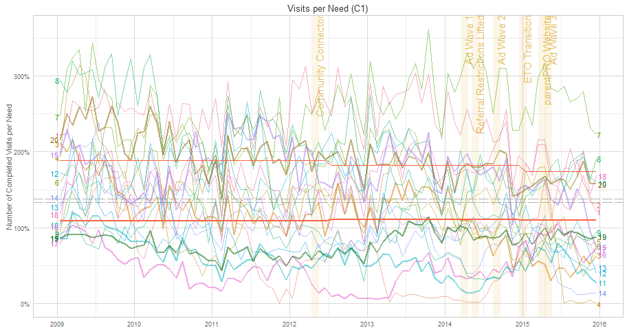

*Response variable*: `VisitCompletedCount`; *Offset variable*: `InfantNeedCountForTime`

## 6.1 Two-rate coding –MIECHV Contracted

```
               coefficient letter   beta change     p
1               MiechvEver      a -0.545   0.58  .001
2                  Cohort1      b -0.031   0.97  .314
3                  Cohort2      c -0.081   0.92  .096
4 Cohort1:MiechvContracted      d  0.045   1.05  .158
5 Cohort2:MiechvContracted      e  0.090   1.09  .152
Generalized linear mixed model fit by maximum likelihood (Adaptive Gauss-Hermite Quadrature, nAGQ
  = 0) [glmerMod]
 Family: poisson  ( log )
Formula: VisitCompletedCount ~ 1 + MiechvEver + Cohort1 + Cohort2 + MiechvContracted:Cohort1 +
    MiechvContracted:Cohort2 + Lag1 + Lag2 + Lag3 + (1 + Cohort1 +
    Cohort2 + Lag1 + Lag2 + Lag3 | RegionID) + (1 | QuarterF) +
    offset(log(InfantNeedCountForTime))
   Data: d

     AIC      BIC   logLik deviance df.resid
 15732.9  15900.0  -7835.5  15670.9     1589

Random effects:
 Groups   Name        Variance Std.Dev. Corr
 QuarterF (Intercept) 0.003389 0.05822
 RegionID (Intercept) 0.365273 0.60438
          Cohort1     0.004513 0.06718  -0.05
          Cohort2     0.015370 0.12398  -0.25  0.32
          Lag1        0.028311 0.16826  -0.28 -0.30  0.21
          Lag2        0.002848 0.05337  -0.53 -0.20 -0.20 -0.47
          Lag3        0.007945 0.08913   0.04  0.46 -0.25 -0.92  0.58
Number of obs: 1620, groups:  QuarterF, 27; RegionID, 20

Fixed effects:
                         Estimate Std. Error z value Pr(>|z|)
(Intercept)              -2.75031    0.16132 -17.049  < 2e-16 ***
MiechvEver               -0.54475    0.17011  -3.202  0.00136 **
Cohort1                  -0.03130    0.03108  -1.007  0.31399
Cohort2                  -0.08096    0.04860  -1.666  0.09574 .
Lag1                      0.33050    0.04046   8.169 3.12e-16 ***
Lag2                      0.24671    0.01835  13.447  < 2e-16 ***
Lag3                      0.10399    0.02366   4.394 1.11e-05 ***
Cohort1:MiechvContracted  0.04485    0.03179   1.411  0.15829
Cohort2:MiechvContracted  0.08968    0.06253   1.434  0.15155
---
Signif. codes:  0 '***' 0.001 '**' 0.01 '*' 0.05 '.' 0.1 ' ' 1
```

### 6.1.1 Increment coding –MIECHV Contracted

```
                  coefficient letter   beta change     p
1                  MiechvEver      a -0.642   0.53  .001
2                  Cohort1Or2      b -0.002   1.00  .942
3                     Cohort2      c -0.003   1.00  .931
4 Cohort1Or2:MiechvContracted      d  0.028   1.03  .003
5    Cohort2:MiechvContracted      e  0.035   1.04  .014
      AIC       BIC    logLik  deviance  df.resid
15885.026 15992.830 -7922.513 15845.026  1600.000
```

## 6.2 Two-rate coding –MIECHV Staffed

```
            coefficient letter   beta change     p
1            MiechvEver      a -0.522   0.59 <.001
2               Cohort1      b -0.022   0.98  .464
3               Cohort2      c -0.088   0.92  .053
4 Cohort1:MiechvStaffed      d  0.019   1.02  .147
5 Cohort2:MiechvStaffed      e  0.126   1.13 <.001
      AIC       BIC    logLik  deviance  df.resid
15709.798 15876.894 -7823.899 15647.798  1589.000
```

### 6.2.1 Increment coding –MIECHV Staffed

```
               coefficient letter   beta change     p
1               MiechvEver      a -0.684   0.50 <.001
2               Cohort1Or2      b  0.002   1.00  .927
3                  Cohort2      c -0.010   0.99  .790
4 Cohort1Or2:MiechvStaffed      d  0.022   1.02  .013
5    Cohort2:MiechvStaffed      e  0.063   1.07 <.001
      AIC       BIC    logLik  deviance  df.resid
15866.847 15974.651 -7913.424 15826.847  1600.000
```

## 6.3 Two-rate coding –Has Community Connector

```
           coefficient letter   beta change     p
1           MiechvEver      a -0.426   0.65  .003
2              Cohort1      b -0.031   0.97  .315
3              Cohort2      c -0.067   0.93  .146
4 Cohort1:HasConnector      d  0.049   1.05  .035
5 Cohort2:HasConnector      e  0.052   1.05  .236
      AIC       BIC    logLik  deviance  df.resid
15731.419 15898.515 -7834.709 15669.419  1589.000
```

### 6.3.1 Increment coding –Has Community Connector

```
              coefficient letter   beta change     p
1              MiechvEver      a -0.629   0.53  .001
2              Cohort1Or2      b  0.002   1.00  .952
3                 Cohort2      c  0.003   1.00  .929
4 Cohort1Or2:HasConnector      d  0.022   1.02  .020
5    Cohort2:HasConnector      e  0.025   1.03  .076
      AIC       BIC    logLik  deviance  df.resid
15893.802 16001.605 -7926.901 15853.802  1600.000
```

## 6.4 Event: Ad Waves

*Event Description*: parentPRO ad campaigns in 2014 and 2015 - Apr 01, 2014

```
  coefficient letter  beta change     p
1   AdWaveAny      h 0.024   1.02  .003
2  Cohort1Or2      i 0.008   1.01  .101
      AIC       BIC    logLik  deviance  df.resid
16524.990 16611.233 -8246.495 16492.990  1604.000
```

## 6.5 Event: Ad Waves Lagged

*Event Description*: parentPRO ad campaigns in 2014 and 2015 - Jun 01, 2014

```
      coefficient letter  beta change     p
1 AdWaveAnyLagged      h 0.044   1.05 <.001
2      Cohort1Or2      i 0.008   1.01  .075
      AIC       BIC    logLik  deviance  df.resid
16519.321 16605.564 -8243.661 16487.321  1604.000
```

## 6.6 Event: Ad Wave 1

*Event Description*: parentPRO ad campaign concentrated in May. - Apr 01, 2014

```
  coefficient letter  beta change     p
1     AdWave1      h 0.009   1.01  .423
2  Cohort1Or2      i 0.011   1.01  .026
      AIC       BIC    logLik  deviance  df.resid
16532.938 16619.181 -8250.469 16500.938  1604.000
```

## 6.7 Event: Ad Wave 1 Lagged

*Event Description*: parentPRO ad campaign concentrated in May. - Jun 01, 2014

```
    coefficient letter  beta change     p
1 AdWave1Lagged      h 0.000   1.00  .985
2    Cohort1Or2      i 0.011   1.01  .019
      AIC       BIC    logLik  deviance  df.resid
16533.578 16619.821 -8250.789 16501.578  1604.000
```

## 6.8 Event: Ad Wave 2

*Event Description*: parentPRO ad campaign concentrated in late Sept. - Sep 01, 2014

```
  coefficient letter  beta change     p
1     AdWave2      h 0.091   1.10 <.001
2  Cohort1Or2      i 0.007   1.01  .138
     AIC      BIC   logLik deviance df.resid
16490.40 16576.64 -8229.20 16458.40  1604.00
```

## 6.9 Event: Ad Wave 2 Lagged

*Event Description*: parentPRO ad campaign concentrated in late Sept. - Oct 01, 2014

```
    coefficient letter  beta change     p
1 AdWave2Lagged      h 0.124   1.13 <.001
2    Cohort1Or2      i 0.008   1.01  .082
      AIC       BIC    logLik  deviance  df.resid
16491.327 16577.570 -8229.663 16459.327  1604.000
```